# Math anxiety (MA) & Math performance

Giona Silei

## Importing the Sara_dataset.xls into R

```r
library(tidyverse)
library(readxl)

dataset <- read_excel("Sara_dataset.xls")
```

First lets load the needed packages.<sup>1</sup>

Then lets import the Sara_dataset into R using the `read_excel()` function.

[^1]: package `readxl` is loaded separately because it’s not part of the core tidyverse.

```r
glimpse(dataset)
```

```
Rows: 100
Columns: 13
$ gender   <dbl> 1, 1, 1, 1, 1, 1, 1, 1, 1, 1, 1, 1, 1, 1, 1, 1, 1, 1, 1, 1, 1…
$ major    <dbl> 1, 1, 1, 1, 1, 1, 1, 1, 1, 1, 1, 1, 1, 1, 1, 1, 1, 1, 1, 2, 2…
$ cond     <dbl> 1, 1, 1, 1, 1, 2, 2, 2, 2, 2, 4, 2, 2, 3, 4, 4, 2, 4, 4, 1, 1…
$ phobia   <dbl> 1, 1, 4, 4, 10, 4, 4, 4, 4, 5, 3, 5, 4, 4, 8, 4, 7, 0, 5, 4, …
$ prevmath <dbl> 3, 4, 1, 0, 1, 1, 2, 1, 1, 0, 1, 1, 0, 1, 0, 1, 0, 3, 1, 2, 2…
$ mathquiz <dbl> 43, 49, 26, 29, 31, 20, 13, 23, 38, NA, 21, 29, 32, NA, NA, 3…
$ statquiz <dbl> 6, 9, 8, 7, 6, 7, 3, 7, 8, 7, 8, 8, 8, 5, 3, 8, 1, 10, 7, 7, …
$ hr_base  <dbl> 71, 73, 69, 72, 71, 70, 71, 77, 73, 78, 72, 74, 73, 72, 76, 6…
$ hr_pre   <dbl> 68, 75, 76, 73, 83, 71, 70, 87, 72, 76, 74, 72, 74, 83, 76, 6…
$ hr_post  <dbl> 65, 68, 72, 78, 74, 76, 66, 84, 67, 74, 68, 73, 74, 77, 79, 7…
$ anx_base <dbl> 17, 17, 19, 19, 26, 12, 12, 17, 20, 20, 21, 21, 32, 18, 14, 1…
$ anx_pre  <dbl> 22, 19, 14, 13, 30, 15, 16, 19, 14, 24, 27, 25, 35, 27, 18, 1…
$ anx_post <dbl> 20, 16, 15, 16, 25, 19, 17, 22, 17, 19, 22, 22, 33, 28, 21, 1…
```

## Taking a closer look at some of the variables

Sample size  
$n =$ 100

Self-reported fear of mathematics (measured on a 0–10 scale) `phobia`  
$\bar{x} =$ 3.31 $s =$ 2.44

Number of mathematics courses previously attended `prevmath`  
$\bar{x} =$ 1.38 $s =$ 1.25

Score on a mathematics pre-test (measured on a 0-50 scale) `mathquiz`  
$\bar{x} =$ 29.07 $s =$ 9.48

Score on a statistics test(measured on a 0-10 scale) `statquiz`  
$\bar{x} =$ 6.86 $s =$ 1.7

# Analysing the variables

## Math pre-test

Self reported fear of mathematics and performance in the mathematics pre-test are negatively correlated  
(**$r =$ -0.28**)<sup>1</sup>

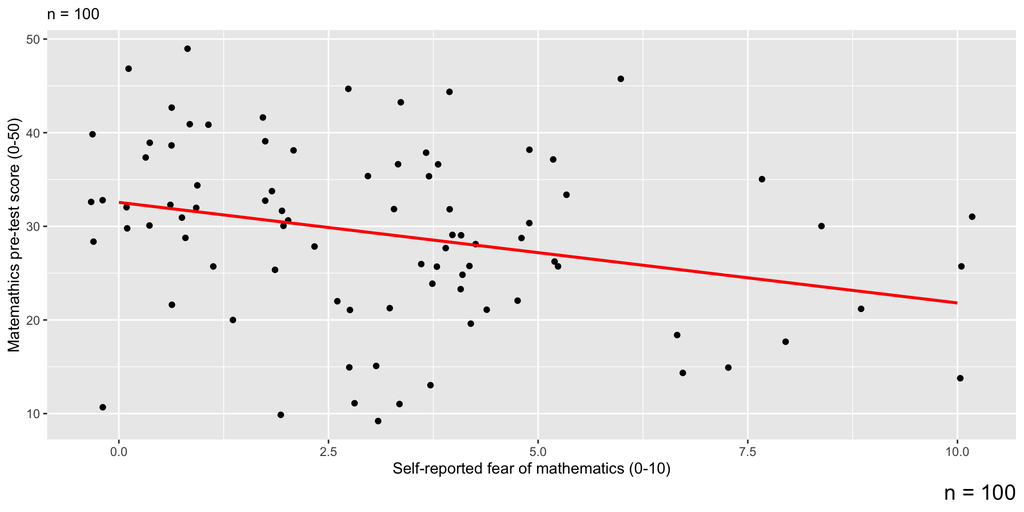

[^2]: *Pearson’s* $r$, calculated with $\frac{s_{xy}}{s_{x}s_{y}}$

## Stat pre-test

Self reported fear of mathematics and performance in the statistics pre-test are negatively correlated  
(**$r =$ -0.39**)<sup>1</sup>

[figure not shown]

[^3]: *Pearson’s* $r$, calculated with $\frac{s_{xy}}{s_{x}s_{y}}$

## Summarizing the results

**Variable**  
Self-reported fear of mathematics (0–10 scale)  
Score on a mathematics pre-test (0-50 scale)  
Score on a statistics pre-test (0-10 scale)

$r$<sup>3</sup>  
1  
-0.28  
-0.39

[^4]: sample mean, calculated with $\frac{\sum_{i=1}^{n} x_i}{n}$
[^5]: sample standard deviation, calculated with $\sqrt{s^{2}}$
[^6]: correlation with self-reported fear of mathematics, calculated using *Pearson’s* $r$ ($\frac{s_{xy}}{s_{x}s_{y}}$)